# Risk Factor Analysis

## Outcome Variable

**Outcome Variable:** whz

## Predictor Variables

**Intervention Variable:** mbmi

**Adjustment Set:**

- arm
- W_mage
- meducyrs
- feducyrs
- hhwealth_quart
- W_nrooms
- W_nchldlt5
- brthmon
- W_parity
- impfloor
- impsan
- safeh20
- W_gagebrth
- W_birthwt
- W_birthlen
- vagbrth
- parity
- delta_W_mage
- delta_meducyrs
- delta_feducyrs
- delta_hhwealth_quart
- delta_W_nrooms
- delta_W_nchldlt5
- delta_brthmon
- delta_W_parity
- delta_impfloor
- delta_impsan
- delta_safeh20
- delta_W_gagebrth
- delta_W_birthwt
- delta_W_birthlen
- delta_vagbrth
- delta_parity

## Stratifying Variables

The analysis was stratified on these variable(s):

- agecat
- studyid
- country

## Data Summary

| agecat | studyid | country | mbmi | n_cell | n | outcome_variable |
| --- | --- | --- | --- | --- | --- | --- |
| 6 months | ki0047075b-MAL-ED | BANGLADESH | Normal weight | 209 | 241 | whz |
| 6 months | ki0047075b-MAL-ED | BANGLADESH | Underweight | 32 | 241 | whz |
| 6 months | ki0047075b-MAL-ED | BRAZIL | Normal weight | 199 | 208 | whz |
| 6 months | ki0047075b-MAL-ED | BRAZIL | Underweight | 9 | 208 | whz |
| 6 months | ki0047075b-MAL-ED | INDIA | Normal weight | 186 | 235 | whz |
| 6 months | ki0047075b-MAL-ED | INDIA | Underweight | 49 | 235 | whz |
| 6 months | ki0047075b-MAL-ED | NEPAL | Normal weight | 236 | 236 | whz |
| 6 months | ki0047075b-MAL-ED | NEPAL | Underweight | 0 | 236 | whz |
| 6 months | ki0047075b-MAL-ED | PERU | Normal weight | 267 | 272 | whz |
| 6 months | ki0047075b-MAL-ED | PERU | Underweight | 5 | 272 | whz |
| 6 months | ki0047075b-MAL-ED | SOUTH AFRICA | Normal weight | 242 | 249 | whz |
| 6 months | ki0047075b-MAL-ED | SOUTH AFRICA | Underweight | 7 | 249 | whz |
| 6 months | ki0047075b-MAL-ED | TANZANIA, UNITED REPUBLIC OF | Normal weight | 233 | 247 | whz |
| 6 months | ki0047075b-MAL-ED | TANZANIA, UNITED REPUBLIC OF | Underweight | 14 | 247 | whz |
| 6 months | ki1000304b-SAS-CompFeed | INDIA | Normal weight | 902 | 1226 | whz |
| 6 months | ki1000304b-SAS-CompFeed | INDIA | Underweight | 324 | 1226 | whz |
| 6 months | ki1017093-NIH-Birth | BANGLADESH | Normal weight | 444 | 537 | whz |
| 6 months | ki1017093-NIH-Birth | BANGLADESH | Underweight | 93 | 537 | whz |
| 6 months | ki1017093b-PROVIDE | BANGLADESH | Normal weight | 497 | 602 | whz |
| 6 months | ki1017093b-PROVIDE | BANGLADESH | Underweight | 105 | 602 | whz |
| 6 months | ki1017093c-NIH-Crypto | BANGLADESH | Normal weight | 648 | 715 | whz |
| 6 months | ki1017093c-NIH-Crypto | BANGLADESH | Underweight | 67 | 715 | whz |
| 6 months | ki1066203-TanzaniaChild2 | TANZANIA, UNITED REPUBLIC OF | Normal weight | 1949 | 1982 | whz |
| 6 months | ki1066203-TanzaniaChild2 | TANZANIA, UNITED REPUBLIC OF | Underweight | 33 | 1982 | whz |
| 6 months | ki1119695-PROBIT | BELARUS | Normal weight | 12519 | 13024 | whz |
| 6 months | ki1119695-PROBIT | BELARUS | Underweight | 505 | 13024 | whz |
| 6 months | ki1126311-ZVITAMBO | ZIMBABWE | Normal weight | 6881 | 7253 | whz |
| 6 months | ki1126311-ZVITAMBO | ZIMBABWE | Underweight | 372 | 7253 | whz |
| 6 months | ki1148112-LCNI-5 | MALAWI | Normal weight | 691 | 836 | whz |
| 6 months | ki1148112-LCNI-5 | MALAWI | Underweight | 145 | 836 | whz |
| 6 months | kiGH5241-JiVitA-3 | BANGLADESH | Normal weight | 10303 | 16733 | whz |
| 6 months | kiGH5241-JiVitA-3 | BANGLADESH | Underweight | 6430 | 16733 | whz |
| 24 months | ki0047075b-MAL-ED | BANGLADESH | Normal weight | 183 | 212 | whz |
| 24 months | ki0047075b-MAL-ED | BANGLADESH | Underweight | 29 | 212 | whz |
| 24 months | ki0047075b-MAL-ED | BRAZIL | Normal weight | 162 | 168 | whz |
| 24 months | ki0047075b-MAL-ED | BRAZIL | Underweight | 6 | 168 | whz |
| 24 months | ki0047075b-MAL-ED | INDIA | Normal weight | 180 | 226 | whz |
| 24 months | ki0047075b-MAL-ED | INDIA | Underweight | 46 | 226 | whz |
| 24 months | ki0047075b-MAL-ED | NEPAL | Normal weight | 228 | 228 | whz |
| 24 months | ki0047075b-MAL-ED | NEPAL | Underweight | 0 | 228 | whz |
| 24 months | ki0047075b-MAL-ED | PERU | Normal weight | 197 | 201 | whz |
| 24 months | ki0047075b-MAL-ED | PERU | Underweight | 4 | 201 | whz |
| 24 months | ki0047075b-MAL-ED | SOUTH AFRICA | Normal weight | 227 | 234 | whz |
| 24 months | ki0047075b-MAL-ED | SOUTH AFRICA | Underweight | 7 | 234 | whz |
| 24 months | ki0047075b-MAL-ED | TANZANIA, UNITED REPUBLIC OF | Normal weight | 203 | 214 | whz |
| 24 months | ki0047075b-MAL-ED | TANZANIA, UNITED REPUBLIC OF | Underweight | 11 | 214 | whz |
| 24 months | ki1017093-NIH-Birth | BANGLADESH | Normal weight | 348 | 428 | whz |
| 24 months | ki1017093-NIH-Birth | BANGLADESH | Underweight | 80 | 428 | whz |
| 24 months | ki1017093b-PROVIDE | BANGLADESH | Normal weight | 478 | 578 | whz |
| 24 months | ki1017093b-PROVIDE | BANGLADESH | Underweight | 100 | 578 | whz |
| 24 months | ki1017093c-NIH-Crypto | BANGLADESH | Normal weight | 471 | 514 | whz |
| 24 months | ki1017093c-NIH-Crypto | BANGLADESH | Underweight | 43 | 514 | whz |
| 24 months | ki1066203-TanzaniaChild2 | TANZANIA, UNITED REPUBLIC OF | Normal weight | 6 | 6 | whz |
| 24 months | ki1066203-TanzaniaChild2 | TANZANIA, UNITED REPUBLIC OF | Underweight | 0 | 6 | whz |
| 24 months | ki1119695-PROBIT | BELARUS | Normal weight | 3801 | 3942 | whz |
| 24 months | ki1119695-PROBIT | BELARUS | Underweight | 141 | 3942 | whz |
| 24 months | ki1126311-ZVITAMBO | ZIMBABWE | Normal weight | 339 | 366 | whz |
| 24 months | ki1126311-ZVITAMBO | ZIMBABWE | Underweight | 27 | 366 | whz |
| 24 months | ki1148112-LCNI-5 | MALAWI | Normal weight | 467 | 561 | whz |
| 24 months | ki1148112-LCNI-5 | MALAWI | Underweight | 94 | 561 | whz |
| 24 months | kiGH5241-JiVitA-3 | BANGLADESH | Normal weight | 5272 | 8570 | whz |
| 24 months | kiGH5241-JiVitA-3 | BANGLADESH | Underweight | 3298 | 8570 | whz |

The following strata were considered:

- agecat: 24 months, studyid: ki0047075b-MAL-ED, country: BANGLADESH
- agecat: 24 months, studyid: ki0047075b-MAL-ED, country: BRAZIL
- agecat: 24 months, studyid: ki0047075b-MAL-ED, country: INDIA
- agecat: 24 months, studyid: ki0047075b-MAL-ED, country: NEPAL
- agecat: 24 months, studyid: ki0047075b-MAL-ED, country: PERU
- agecat: 24 months, studyid: ki0047075b-MAL-ED, country: SOUTH AFRICA
- agecat: 24 months, studyid: ki0047075b-MAL-ED, country: TANZANIA, UNITED REPUBLIC OF
- agecat: 24 months, studyid: ki1017093-NIH-Birth, country: BANGLADESH
- agecat: 24 months, studyid: ki1017093b-PROVIDE, country: BANGLADESH
- agecat: 24 months, studyid: ki1017093c-NIH-Crypto, country: BANGLADESH
- agecat: 24 months, studyid: ki1066203-TanzaniaChild2, country: TANZANIA, UNITED REPUBLIC OF
- agecat: 24 months, studyid: ki1119695-PROBIT, country: BELARUS
- agecat: 24 months, studyid: ki1126311-ZVITAMBO, country: ZIMBABWE
- agecat: 24 months, studyid: ki1148112-LCNI-5, country: MALAWI
- agecat: 24 months, studyid: kiGH5241-JiVitA-3, country: BANGLADESH
- agecat: 6 months, studyid: ki0047075b-MAL-ED, country: BANGLADESH
- agecat: 6 months, studyid: ki0047075b-MAL-ED, country: BRAZIL
- agecat: 6 months, studyid: ki0047075b-MAL-ED, country: INDIA
- agecat: 6 months, studyid: ki0047075b-MAL-ED, country: NEPAL
- agecat: 6 months, studyid: ki0047075b-MAL-ED, country: PERU
- agecat: 6 months, studyid: ki0047075b-MAL-ED, country: SOUTH AFRICA
- agecat: 6 months, studyid: ki0047075b-MAL-ED, country: TANZANIA, UNITED REPUBLIC OF
- agecat: 6 months, studyid: ki1000304b-SAS-CompFeed, country: INDIA
- agecat: 6 months, studyid: ki1017093-NIH-Birth, country: BANGLADESH
- agecat: 6 months, studyid: ki1017093b-PROVIDE, country: BANGLADESH
- agecat: 6 months, studyid: ki1017093c-NIH-Crypto, country: BANGLADESH
- agecat: 6 months, studyid: ki1066203-TanzaniaChild2, country: TANZANIA, UNITED REPUBLIC OF
- agecat: 6 months, studyid: ki1119695-PROBIT, country: BELARUS
- agecat: 6 months, studyid: ki1126311-ZVITAMBO, country: ZIMBABWE
- agecat: 6 months, studyid: ki1148112-LCNI-5, country: MALAWI
- agecat: 6 months, studyid: kiGH5241-JiVitA-3, country: BANGLADESH

### Dropped Strata

Some strata were dropped due to rare outcomes:

- agecat: 6 months, studyid: ki0047075b-MAL-ED, country: NEPAL
- agecat: 24 months, studyid: ki0047075b-MAL-ED, country: NEPAL
- agecat: 24 months, studyid: ki0047075b-MAL-ED, country: PERU
- agecat: 24 months, studyid: ki1066203-TanzaniaChild2, country: TANZANIA, UNITED REPUBLIC OF

## Methods Detail

We’re interested in the causal parameters $E[Y_a]$ for all values of $a \in \mathcal{A}$. These parameters represent the mean outcome if, possibly contrary to fact, we intervened to set all units to have $A=a$. Under the randomization and positivity assumptions, these are identified by the statistical parameters $\psi_a=E_W[E_{Y|A,W}(Y|A=a,W)]$. In addition, we’re interested in the mean of $Y$, $E[Y]$ under no intervention (the observed mean). We will estimate these parameters by using SuperLearner to fit the relevant likelihood factors – $E_{Y|A,W}(Y|A=a,W)$ and $p(A=a|W)$, and then updating our likelihood fit using a joint TMLE.

For unadjusted analyses ($W=\{\}$), initial likelihoods were estimated using Lrnr_glm to estimate the simple $E(Y|A)$ and Lrnr_mean to estimate $p(A)$. For adjusted analyses, a small library containing Lrnr_glmnet, Lrnr_xgboost, and Lrnr_mean was used.

# Results Detail

## Results Plots

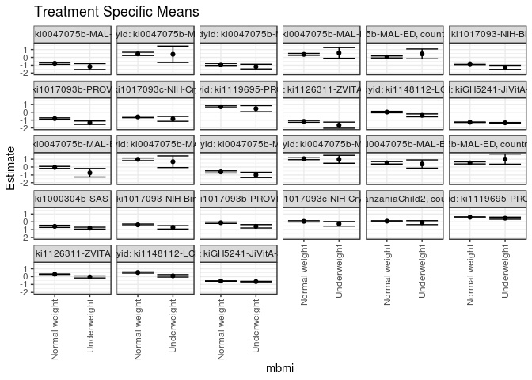

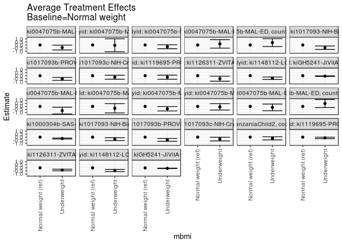

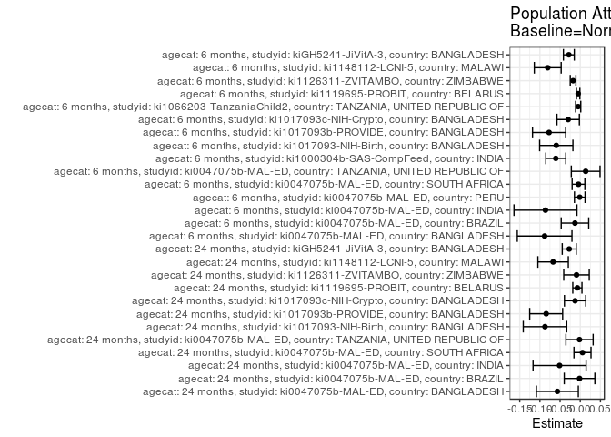

## Results Table

### Parameter: TSM

| agecat | studyid | country | intervention_level | baseline_level | estimate | ci_lower | ci_upper |
| --- | --- | --- | --- | --- | --- | --- | --- |
| 6 months | ki0047075b-MAL-ED | BANGLADESH | Normal weight | NA | -0.0493243 | -0.1782069 | 0.0795583 |
| 6 months | ki0047075b-MAL-ED | BANGLADESH | Underweight | NA | -0.7287536 | -1.2684986 | -0.1890087 |
| 6 months | ki0047075b-MAL-ED | BRAZIL | Normal weight | NA | 0.9779606 | 0.8096461 | 1.1462751 |
| 6 months | ki0047075b-MAL-ED | BRAZIL | Underweight | NA | 0.6750000 | -0.0698801 | 1.4198801 |
| 6 months | ki0047075b-MAL-ED | INDIA | Normal weight | NA | -0.6171610 | -0.7494444 | -0.4848775 |
| 6 months | ki0047075b-MAL-ED | INDIA | Underweight | NA | -0.9971467 | -1.3367883 | -0.6575051 |
| 6 months | ki0047075b-MAL-ED | PERU | Normal weight | NA | 1.0561298 | 0.9317231 | 1.1805366 |
| 6 months | ki0047075b-MAL-ED | PERU | Underweight | NA | 0.9870000 | 0.4781587 | 1.4958413 |
| 6 months | ki0047075b-MAL-ED | SOUTH AFRICA | Normal weight | NA | 0.5335468 | 0.3758513 | 0.6912424 |
| 6 months | ki0047075b-MAL-ED | SOUTH AFRICA | Underweight | NA | 0.3771429 | -0.1498294 | 0.9041151 |
| 6 months | ki0047075b-MAL-ED | TANZANIA, UNITED REPUBLIC OF | Normal weight | NA | 0.5227775 | 0.3851658 | 0.6603891 |
| 6 months | ki0047075b-MAL-ED | TANZANIA, UNITED REPUBLIC OF | Underweight | NA | 1.0068286 | 0.3561823 | 1.6574749 |
| 6 months | ki1000304b-SAS-CompFeed | INDIA | Normal weight | NA | -0.5819841 | -0.7189213 | -0.4450469 |
| 6 months | ki1000304b-SAS-CompFeed | INDIA | Underweight | NA | -0.8074743 | -0.9239730 | -0.6909756 |
| 6 months | ki1017093-NIH-Birth | BANGLADESH | Normal weight | NA | -0.3879538 | -0.4877934 | -0.2881141 |
| 6 months | ki1017093-NIH-Birth | BANGLADESH | Underweight | NA | -0.7105006 | -0.9261361 | -0.4948651 |
| 6 months | ki1017093b-PROVIDE | BANGLADESH | Normal weight | NA | -0.1214147 | -0.2114941 | -0.0313354 |
| 6 months | ki1017093b-PROVIDE | BANGLADESH | Underweight | NA | -0.5771884 | -0.7921271 | -0.3622497 |
| 6 months | ki1017093c-NIH-Crypto | BANGLADESH | Normal weight | NA | 0.0597266 | -0.0218209 | 0.1412740 |
| 6 months | ki1017093c-NIH-Crypto | BANGLADESH | Underweight | NA | -0.2591452 | -0.5520167 | 0.0337263 |
| 6 months | ki1066203-TanzaniaChild2 | TANZANIA, UNITED REPUBLIC OF | Normal weight | NA | 0.0826782 | 0.0283308 | 0.1370256 |
| 6 months | ki1066203-TanzaniaChild2 | TANZANIA, UNITED REPUBLIC OF | Underweight | NA | -0.1120249 | -0.3667247 | 0.1426748 |
| 6 months | ki1119695-PROBIT | BELARUS | Normal weight | NA | 0.5882063 | 0.5303456 | 0.6460670 |
| 6 months | ki1119695-PROBIT | BELARUS | Underweight | NA | 0.4652837 | 0.3324859 | 0.5980815 |
| 6 months | ki1126311-ZVITAMBO | ZIMBABWE | Normal weight | NA | 0.3126717 | 0.2845281 | 0.3408153 |
| 6 months | ki1126311-ZVITAMBO | ZIMBABWE | Underweight | NA | -0.0393284 | -0.1746194 | 0.0959626 |
| 6 months | ki1148112-LCNI-5 | MALAWI | Normal weight | NA | 0.5321414 | 0.4539656 | 0.6103172 |
| 6 months | ki1148112-LCNI-5 | MALAWI | Underweight | NA | 0.0975625 | -0.0609497 | 0.2560747 |
| 6 months | kiGH5241-JiVitA-3 | BANGLADESH | Normal weight | NA | -0.5648879 | -0.5876710 | -0.5421048 |
| 6 months | kiGH5241-JiVitA-3 | BANGLADESH | Underweight | NA | -0.6391382 | -0.6693590 | -0.6089173 |
| 24 months | ki0047075b-MAL-ED | BANGLADESH | Normal weight | NA | -0.7625731 | -0.8925747 | -0.6325715 |
| 24 months | ki0047075b-MAL-ED | BANGLADESH | Underweight | NA | -1.1806347 | -1.5542739 | -0.8069956 |
| 24 months | ki0047075b-MAL-ED | BRAZIL | Normal weight | NA | 0.4461317 | 0.2381826 | 0.6540808 |
| 24 months | ki0047075b-MAL-ED | BRAZIL | Underweight | NA | 0.3966667 | -0.6451983 | 1.4385316 |
| 24 months | ki0047075b-MAL-ED | INDIA | Normal weight | NA | -0.9006486 | -1.0245991 | -0.7766981 |
| 24 months | ki0047075b-MAL-ED | INDIA | Underweight | NA | -1.1886513 | -1.4884737 | -0.8888290 |
| 24 months | ki0047075b-MAL-ED | SOUTH AFRICA | Normal weight | NA | 0.3861417 | 0.2630585 | 0.5092249 |
| 24 months | ki0047075b-MAL-ED | SOUTH AFRICA | Underweight | NA | 0.5700000 | -0.1123856 | 1.2523856 |
| 24 months | ki0047075b-MAL-ED | TANZANIA, UNITED REPUBLIC OF | Normal weight | NA | 0.0566662 | -0.0706273 | 0.1839596 |
| 24 months | ki0047075b-MAL-ED | TANZANIA, UNITED REPUBLIC OF | Underweight | NA | 0.4463174 | -0.1800862 | 1.0727211 |
| 24 months | ki1017093-NIH-Birth | BANGLADESH | Normal weight | NA | -0.8241683 | -0.9278564 | -0.7204801 |
| 24 months | ki1017093-NIH-Birth | BANGLADESH | Underweight | NA | -1.2753198 | -1.5409575 | -1.0096822 |
| 24 months | ki1017093b-PROVIDE | BANGLADESH | Normal weight | NA | -0.8069533 | -0.8958361 | -0.7180705 |
| 24 months | ki1017093b-PROVIDE | BANGLADESH | Underweight | NA | -1.3285294 | -1.5482003 | -1.1088585 |
| 24 months | ki1017093c-NIH-Crypto | BANGLADESH | Normal weight | NA | -0.5974926 | -0.6963488 | -0.4986363 |
| 24 months | ki1017093c-NIH-Crypto | BANGLADESH | Underweight | NA | -0.8443852 | -1.1550648 | -0.5337056 |
| 24 months | ki1119695-PROBIT | BELARUS | Normal weight | NA | 0.6952393 | 0.5856479 | 0.8048307 |
| 24 months | ki1119695-PROBIT | BELARUS | Underweight | NA | 0.4495975 | 0.0621425 | 0.8370526 |
| 24 months | ki1126311-ZVITAMBO | ZIMBABWE | Normal weight | NA | -1.1625309 | -1.2758848 | -1.0491770 |
| 24 months | ki1126311-ZVITAMBO | ZIMBABWE | Underweight | NA | -1.6468701 | -2.0406926 | -1.2530476 |
| 24 months | ki1148112-LCNI-5 | MALAWI | Normal weight | NA | 0.0204277 | -0.0687271 | 0.1095825 |
| 24 months | ki1148112-LCNI-5 | MALAWI | Underweight | NA | -0.3956082 | -0.5774488 | -0.2137676 |
| 24 months | kiGH5241-JiVitA-3 | BANGLADESH | Normal weight | NA | -1.2697531 | -1.2990900 | -1.2404162 |
| 24 months | kiGH5241-JiVitA-3 | BANGLADESH | Underweight | NA | -1.3404651 | -1.3764541 | -1.3044761 |

### Parameter: E(Y)

| agecat | studyid | country | intervention_level | baseline_level | estimate | ci_lower | ci_upper |
| --- | --- | --- | --- | --- | --- | --- | --- |
| 6 months | ki0047075b-MAL-ED | BANGLADESH | NA | NA | -0.1376763 | -0.2664642 | -0.0088885 |
| 6 months | ki0047075b-MAL-ED | BRAZIL | NA | NA | 0.9648518 | 0.8004118 | 1.1292917 |
| 6 months | ki0047075b-MAL-ED | INDIA | NA | NA | -0.7034149 | -0.8300527 | -0.5767771 |
| 6 months | ki0047075b-MAL-ED | PERU | NA | NA | 1.0548591 | 0.9328922 | 1.1768259 |
| 6 months | ki0047075b-MAL-ED | SOUTH AFRICA | NA | NA | 0.5291499 | 0.3751396 | 0.6831602 |
| 6 months | ki0047075b-MAL-ED | TANZANIA, UNITED REPUBLIC OF | NA | NA | 0.5362213 | 0.4049390 | 0.6675036 |
| 6 months | ki1000304b-SAS-CompFeed | INDIA | NA | NA | -0.6426305 | -0.7702214 | -0.5150396 |
| 6 months | ki1017093-NIH-Birth | BANGLADESH | NA | NA | -0.4474038 | -0.5378167 | -0.3569909 |
| 6 months | ki1017093b-PROVIDE | BANGLADESH | NA | NA | -0.1987071 | -0.2815473 | -0.1158669 |
| 6 months | ki1017093c-NIH-Crypto | BANGLADESH | NA | NA | 0.0297622 | -0.0491685 | 0.1086930 |
| 6 months | ki1066203-TanzaniaChild2 | TANZANIA, UNITED REPUBLIC OF | NA | NA | 0.0775172 | 0.0241750 | 0.1308595 |
| 6 months | ki1119695-PROBIT | BELARUS | NA | NA | 0.5829956 | 0.5247249 | 0.6412663 |
| 6 months | ki1126311-ZVITAMBO | ZIMBABWE | NA | NA | 0.2948332 | 0.2672524 | 0.3224139 |
| 6 months | ki1148112-LCNI-5 | MALAWI | NA | NA | 0.4515550 | 0.3802638 | 0.5228463 |
| 6 months | kiGH5241-JiVitA-3 | BANGLADESH | NA | NA | -0.5931545 | -0.6127055 | -0.5736036 |
| 24 months | ki0047075b-MAL-ED | BANGLADESH | NA | NA | -0.8192925 | -0.9412667 | -0.6973182 |
| 24 months | ki0047075b-MAL-ED | BRAZIL | NA | NA | 0.4443651 | 0.2404149 | 0.6483153 |
| 24 months | ki0047075b-MAL-ED | INDIA | NA | NA | -0.9519248 | -1.0678488 | -0.8360007 |
| 24 months | ki0047075b-MAL-ED | SOUTH AFRICA | NA | NA | 0.3916417 | 0.2704414 | 0.5128421 |
| 24 months | ki0047075b-MAL-ED | TANZANIA, UNITED REPUBLIC OF | NA | NA | 0.0547975 | -0.0703378 | 0.1799328 |
| 24 months | ki1017093-NIH-Birth | BANGLADESH | NA | NA | -0.9115790 | -1.0095022 | -0.8136559 |
| 24 months | ki1017093b-PROVIDE | BANGLADESH | NA | NA | -0.8914360 | -0.9741797 | -0.8086923 |
| 24 months | ki1017093c-NIH-Crypto | BANGLADESH | NA | NA | -0.6103502 | -0.7050157 | -0.5156847 |
| 24 months | ki1119695-PROBIT | BELARUS | NA | NA | 0.6880695 | 0.5737062 | 0.8024328 |
| 24 months | ki1126311-ZVITAMBO | ZIMBABWE | NA | NA | -1.1718579 | -1.2809898 | -1.0627260 |
| 24 months | ki1148112-LCNI-5 | MALAWI | NA | NA | -0.0468717 | -0.1290135 | 0.0352701 |
| 24 months | kiGH5241-JiVitA-3 | BANGLADESH | NA | NA | -1.2970642 | -1.3203662 | -1.2737621 |

### Parameter: ATE

| agecat | studyid | country | intervention_level | baseline_level | estimate | ci_lower | ci_upper |
| --- | --- | --- | --- | --- | --- | --- | --- |
| 6 months | ki0047075b-MAL-ED | BANGLADESH | Normal weight | Normal weight | 0.0000000 | 0.0000000 | 0.0000000 |
| 6 months | ki0047075b-MAL-ED | BANGLADESH | Underweight | Normal weight | -0.6794293 | -1.2343060 | -0.1245527 |
| 6 months | ki0047075b-MAL-ED | BRAZIL | Normal weight | Normal weight | 0.0000000 | 0.0000000 | 0.0000000 |
| 6 months | ki0047075b-MAL-ED | BRAZIL | Underweight | Normal weight | -0.3029606 | -1.0666204 | 0.4606991 |
| 6 months | ki0047075b-MAL-ED | INDIA | Normal weight | Normal weight | 0.0000000 | 0.0000000 | 0.0000000 |
| 6 months | ki0047075b-MAL-ED | INDIA | Underweight | Normal weight | -0.3799857 | -0.7457599 | -0.0142116 |
| 6 months | ki0047075b-MAL-ED | PERU | Normal weight | Normal weight | 0.0000000 | 0.0000000 | 0.0000000 |
| 6 months | ki0047075b-MAL-ED | PERU | Underweight | Normal weight | -0.0691298 | -0.5929586 | 0.4546989 |
| 6 months | ki0047075b-MAL-ED | SOUTH AFRICA | Normal weight | Normal weight | 0.0000000 | 0.0000000 | 0.0000000 |
| 6 months | ki0047075b-MAL-ED | SOUTH AFRICA | Underweight | Normal weight | -0.1564040 | -0.7064654 | 0.3936575 |
| 6 months | ki0047075b-MAL-ED | TANZANIA, UNITED REPUBLIC OF | Normal weight | Normal weight | 0.0000000 | 0.0000000 | 0.0000000 |
| 6 months | ki0047075b-MAL-ED | TANZANIA, UNITED REPUBLIC OF | Underweight | Normal weight | 0.4840511 | -0.1807900 | 1.1488923 |
| 6 months | ki1000304b-SAS-CompFeed | INDIA | Normal weight | Normal weight | 0.0000000 | 0.0000000 | 0.0000000 |
| 6 months | ki1000304b-SAS-CompFeed | INDIA | Underweight | Normal weight | -0.2254902 | -0.3049808 | -0.1459996 |
| 6 months | ki1017093-NIH-Birth | BANGLADESH | Normal weight | Normal weight | 0.0000000 | 0.0000000 | 0.0000000 |
| 6 months | ki1017093-NIH-Birth | BANGLADESH | Underweight | Normal weight | -0.3225468 | -0.5590174 | -0.0860762 |
| 6 months | ki1017093b-PROVIDE | BANGLADESH | Normal weight | Normal weight | 0.0000000 | 0.0000000 | 0.0000000 |
| 6 months | ki1017093b-PROVIDE | BANGLADESH | Underweight | Normal weight | -0.4557737 | -0.6886697 | -0.2228777 |
| 6 months | ki1017093c-NIH-Crypto | BANGLADESH | Normal weight | Normal weight | 0.0000000 | 0.0000000 | 0.0000000 |
| 6 months | ki1017093c-NIH-Crypto | BANGLADESH | Underweight | Normal weight | -0.3188717 | -0.6220457 | -0.0156977 |
| 6 months | ki1066203-TanzaniaChild2 | TANZANIA, UNITED REPUBLIC OF | Normal weight | Normal weight | 0.0000000 | 0.0000000 | 0.0000000 |
| 6 months | ki1066203-TanzaniaChild2 | TANZANIA, UNITED REPUBLIC OF | Underweight | Normal weight | -0.1947031 | -0.4557570 | 0.0663508 |
| 6 months | ki1119695-PROBIT | BELARUS | Normal weight | Normal weight | 0.0000000 | 0.0000000 | 0.0000000 |
| 6 months | ki1119695-PROBIT | BELARUS | Underweight | Normal weight | -0.1229226 | -0.2386037 | -0.0072416 |
| 6 months | ki1126311-ZVITAMBO | ZIMBABWE | Normal weight | Normal weight | 0.0000000 | 0.0000000 | 0.0000000 |
| 6 months | ki1126311-ZVITAMBO | ZIMBABWE | Underweight | Normal weight | -0.3520001 | -0.4899457 | -0.2140545 |
| 6 months | ki1148112-LCNI-5 | MALAWI | Normal weight | Normal weight | 0.0000000 | 0.0000000 | 0.0000000 |
| 6 months | ki1148112-LCNI-5 | MALAWI | Underweight | Normal weight | -0.4345790 | -0.6115254 | -0.2576325 |
| 6 months | kiGH5241-JiVitA-3 | BANGLADESH | Normal weight | Normal weight | 0.0000000 | 0.0000000 | 0.0000000 |
| 6 months | kiGH5241-JiVitA-3 | BANGLADESH | Underweight | Normal weight | -0.0742503 | -0.1091637 | -0.0393368 |
| 24 months | ki0047075b-MAL-ED | BANGLADESH | Normal weight | Normal weight | 0.0000000 | 0.0000000 | 0.0000000 |
| 24 months | ki0047075b-MAL-ED | BANGLADESH | Underweight | Normal weight | -0.4180616 | -0.8145217 | -0.0216015 |
| 24 months | ki0047075b-MAL-ED | BRAZIL | Normal weight | Normal weight | 0.0000000 | 0.0000000 | 0.0000000 |
| 24 months | ki0047075b-MAL-ED | BRAZIL | Underweight | Normal weight | -0.0494650 | -1.1118799 | 1.0129498 |
| 24 months | ki0047075b-MAL-ED | INDIA | Normal weight | Normal weight | 0.0000000 | 0.0000000 | 0.0000000 |
| 24 months | ki0047075b-MAL-ED | INDIA | Underweight | Normal weight | -0.2880027 | -0.6124117 | 0.0364063 |
| 24 months | ki0047075b-MAL-ED | SOUTH AFRICA | Normal weight | Normal weight | 0.0000000 | 0.0000000 | 0.0000000 |
| 24 months | ki0047075b-MAL-ED | SOUTH AFRICA | Underweight | Normal weight | 0.1838583 | -0.5095388 | 0.8772554 |
| 24 months | ki0047075b-MAL-ED | TANZANIA, UNITED REPUBLIC OF | Normal weight | Normal weight | 0.0000000 | 0.0000000 | 0.0000000 |
| 24 months | ki0047075b-MAL-ED | TANZANIA, UNITED REPUBLIC OF | Underweight | Normal weight | 0.3896513 | -0.2516037 | 1.0309062 |
| 24 months | ki1017093-NIH-Birth | BANGLADESH | Normal weight | Normal weight | 0.0000000 | 0.0000000 | 0.0000000 |
| 24 months | ki1017093-NIH-Birth | BANGLADESH | Underweight | Normal weight | -0.4511516 | -0.7357367 | -0.1665665 |
| 24 months | ki1017093b-PROVIDE | BANGLADESH | Normal weight | Normal weight | 0.0000000 | 0.0000000 | 0.0000000 |
| 24 months | ki1017093b-PROVIDE | BANGLADESH | Underweight | Normal weight | -0.5215761 | -0.7585850 | -0.2845673 |
| 24 months | ki1017093c-NIH-Crypto | BANGLADESH | Normal weight | Normal weight | 0.0000000 | 0.0000000 | 0.0000000 |
| 24 months | ki1017093c-NIH-Crypto | BANGLADESH | Underweight | Normal weight | -0.2468926 | -0.5722531 | 0.0784679 |
| 24 months | ki1119695-PROBIT | BELARUS | Normal weight | Normal weight | 0.0000000 | 0.0000000 | 0.0000000 |
| 24 months | ki1119695-PROBIT | BELARUS | Underweight | Normal weight | -0.2456417 | -0.5873813 | 0.0960978 |
| 24 months | ki1126311-ZVITAMBO | ZIMBABWE | Normal weight | Normal weight | 0.0000000 | 0.0000000 | 0.0000000 |
| 24 months | ki1126311-ZVITAMBO | ZIMBABWE | Underweight | Normal weight | -0.4843391 | -0.8947621 | -0.0739162 |
| 24 months | ki1148112-LCNI-5 | MALAWI | Normal weight | Normal weight | 0.0000000 | 0.0000000 | 0.0000000 |
| 24 months | ki1148112-LCNI-5 | MALAWI | Underweight | Normal weight | -0.4160359 | -0.6184080 | -0.2136638 |
| 24 months | kiGH5241-JiVitA-3 | BANGLADESH | Normal weight | Normal weight | 0.0000000 | 0.0000000 | 0.0000000 |
| 24 months | kiGH5241-JiVitA-3 | BANGLADESH | Underweight | Normal weight | -0.0707120 | -0.1159190 | -0.0255051 |

### Parameter: PAR

| agecat | studyid | country | intervention_level | baseline_level | estimate | ci_lower | ci_upper |
| --- | --- | --- | --- | --- | --- | --- | --- |
| 6 months | ki0047075b-MAL-ED | BANGLADESH | Normal weight | NA | -0.0883521 | -0.1561156 | -0.0205885 |
| 6 months | ki0047075b-MAL-ED | BRAZIL | Normal weight | NA | -0.0131089 | -0.0472021 | 0.0209844 |
| 6 months | ki0047075b-MAL-ED | INDIA | Normal weight | NA | -0.0862539 | -0.1643100 | -0.0081978 |
| 6 months | ki0047075b-MAL-ED | PERU | Normal weight | NA | -0.0012708 | -0.0144131 | 0.0118715 |
| 6 months | ki0047075b-MAL-ED | SOUTH AFRICA | Normal weight | NA | -0.0043969 | -0.0201917 | 0.0113979 |
| 6 months | ki0047075b-MAL-ED | TANZANIA, UNITED REPUBLIC OF | Normal weight | NA | 0.0134439 | -0.0221682 | 0.0490560 |
| 6 months | ki1000304b-SAS-CompFeed | INDIA | Normal weight | NA | -0.0606464 | -0.0854059 | -0.0358868 |
| 6 months | ki1017093-NIH-Birth | BANGLADESH | Normal weight | NA | -0.0594500 | -0.1006741 | -0.0182259 |
| 6 months | ki1017093b-PROVIDE | BANGLADESH | Normal weight | NA | -0.0772924 | -0.1183505 | -0.0362343 |
| 6 months | ki1017093c-NIH-Crypto | BANGLADESH | Normal weight | NA | -0.0299643 | -0.0577566 | -0.0021721 |
| 6 months | ki1066203-TanzaniaChild2 | TANZANIA, UNITED REPUBLIC OF | Normal weight | NA | -0.0051609 | -0.0115516 | 0.0012297 |
| 6 months | ki1119695-PROBIT | BELARUS | Normal weight | NA | -0.0052107 | -0.0094464 | -0.0009750 |
| 6 months | ki1126311-ZVITAMBO | ZIMBABWE | Normal weight | NA | -0.0178385 | -0.0248173 | -0.0108597 |
| 6 months | ki1148112-LCNI-5 | MALAWI | Normal weight | NA | -0.0805864 | -0.1138937 | -0.0472791 |
| 6 months | kiGH5241-JiVitA-3 | BANGLADESH | Normal weight | NA | -0.0282666 | -0.0417415 | -0.0147918 |
| 24 months | ki0047075b-MAL-ED | BANGLADESH | Normal weight | NA | -0.0567193 | -0.1086417 | -0.0047970 |
| 24 months | ki0047075b-MAL-ED | BRAZIL | Normal weight | NA | -0.0017666 | -0.0397355 | 0.0362023 |
| 24 months | ki0047075b-MAL-ED | INDIA | Normal weight | NA | -0.0512762 | -0.1170295 | 0.0144772 |
| 24 months | ki0047075b-MAL-ED | SOUTH AFRICA | Normal weight | NA | 0.0055000 | -0.0156289 | 0.0266289 |
| 24 months | ki0047075b-MAL-ED | TANZANIA, UNITED REPUBLIC OF | Normal weight | NA | -0.0018687 | -0.0356053 | 0.0318680 |
| 24 months | ki1017093-NIH-Birth | BANGLADESH | Normal weight | NA | -0.0874108 | -0.1412981 | -0.0335235 |
| 24 months | ki1017093b-PROVIDE | BANGLADESH | Normal weight | NA | -0.0844827 | -0.1253101 | -0.0436553 |
| 24 months | ki1017093c-NIH-Crypto | BANGLADESH | Normal weight | NA | -0.0128576 | -0.0392408 | 0.0135256 |
| 24 months | ki1119695-PROBIT | BELARUS | Normal weight | NA | -0.0071697 | -0.0185545 | 0.0042150 |
| 24 months | ki1126311-ZVITAMBO | ZIMBABWE | Normal weight | NA | -0.0093270 | -0.0409537 | 0.0222998 |
| 24 months | ki1148112-LCNI-5 | MALAWI | Normal weight | NA | -0.0672994 | -0.1050078 | -0.0295910 |
| 24 months | kiGH5241-JiVitA-3 | BANGLADESH | Normal weight | NA | -0.0273111 | -0.0446912 | -0.0099310 |